# 탐색적 자료분석

## Plasma Citrate Concentration 분석

본 과제에서는 10명의 환자의 시간별 혈장 농도 데이터를 분석해 시간별로 혈장 농도에 유의미한 차이가 존재하는지 분석할 것이다. 분석은 다음과 같은 과정을 거칠 것이다.

```
- 데이터 시각화
- 분산의 안정화
    - Power 이용
    - 다른 변환 이용
- 차이 검정
    - Notch 이용한 차이 시각화
    - Paired T-test로 검정
```

주어진 데이터의 형태는 아래와 같다.

| Patient No. | 8AM | 11AM | 2PM | 5PM | 8PM |
| --- | --- | --- | --- | --- | --- |
| 1 | 93 | 121 | 112 | 117 | 121 |
| 2 | 116 | 135 | 114 | 98 | 135 |
| 3 | 125 | 137 | 119 | 105 | 102 |
| 4 | 144 | 173 | 148 | 124 | 122 |
| 5 | 105 | 119 | 125 | 91 | 133 |
| 6 | 109 | 83 | 109 | 80 | 104 |
| 7 | 89 | 95 | 88 | 91 | 116 |
| 8 | 116 | 128 | 122 | 107 | 119 |
| 9 | 151 | 149 | 141 | 126 | 138 |
| 10 | 137 | 139 | 125 | 109 | 107 |

# 자료 시각화

### - Box plot

각 시간대별로 환자들의 혈장 농도를 Box Plot을 이용해 아래와 같이 시각화해 보았다.

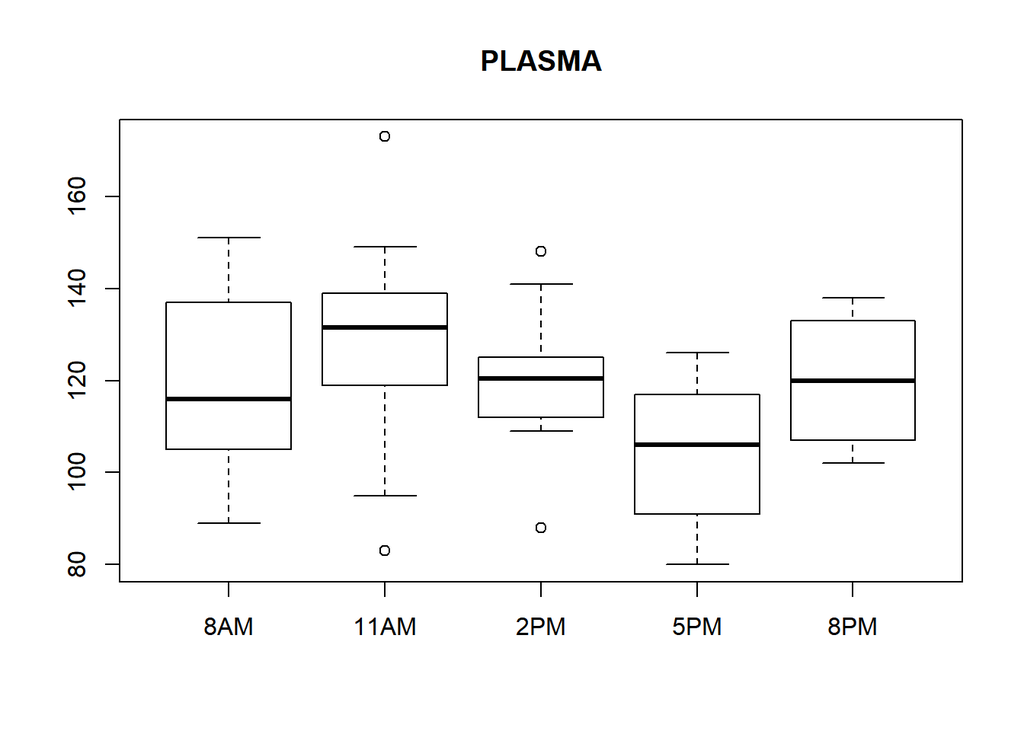

자료를 보면, 평균의 차이가 존재하지만 유의미한 결론에 도달할 수 있는지 정도가 모호하다. 또한 이상값들이 존재하고 분산이 일정하지 않아 분석에 어려움이 있을 것으보 보인다.

# 분산 안정화

### - 안정화 필요 여부 확인

시간대별 H-spread를 구해 분산을 확인할 수 있다. H-spread는 분산보다 이상값의 영향을 덜 받는 지표로, 그 공식은 다음과 같다.

$$\text{H-spread} = \frac{3}{4}(n+1)^{st} statistic-\frac{1}{4}(n+1)^{st} statistic$$

각 시간대별로 H-spread를 구해서 시간대별로 분산의 차이가 있는지 확인하고, 이를 토대로 안정화 필요의 여부를 결정할 수 있다.

```r
Hsp1<-fivenum(plasma$'8AM')[4] - fivenum(plasma$'8AM')[2]
Hsp2<-fivenum(plasma$'11AM')[4] - fivenum(plasma$'11AM')[2]
Hsp3<-fivenum(plasma$'2PM')[4] - fivenum(plasma$'2PM')[2]
Hsp4<-fivenum(plasma$'5PM')[4] - fivenum(plasma$'5PM')[2]
Hsp5<-fivenum(plasma$'8PM')[4] - fivenum(plasma$'8PM')[2]
Hsp<-c(Hsp1,Hsp2,Hsp3,Hsp4,Hsp5)
Hsp
```

```
## [1] 32 20 13 26 26
```

H-spread를 확인해 보면, 분산의 안정화가 필요하다는 것을 알 수 있다.

### - Power를 통한 안정화

분산 안정화에 필요한 power를 구하기 위해 구간의 H-spread와 Median들에 로그를 취해 이에 대해 선형 회귀분석을 해보았다.

```
##
## Call:
## lm(formula = log(Hsp) ~ log(M))
##
## Coefficients:
## (Intercept)       log(M)
##       11.66        -1.79
```

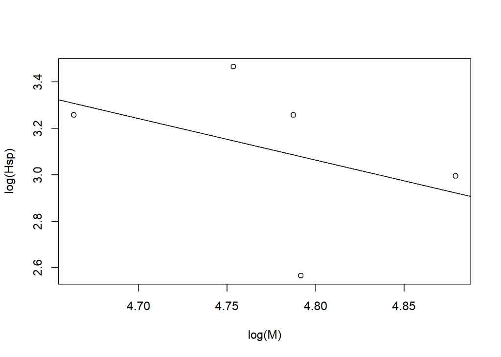

```
##   log(M)
## 2.790418
```

회귀선에서 심하게 벗어난 점이 하나 있지만, 우선 회귀선의 계수를 이용해 power를 구해본 결과, 값은 2.79가 나왔다. 2.79는 3과 근접하므로 raw data에 세제곱을 해서 분산 안정화를 시도해 보았다.

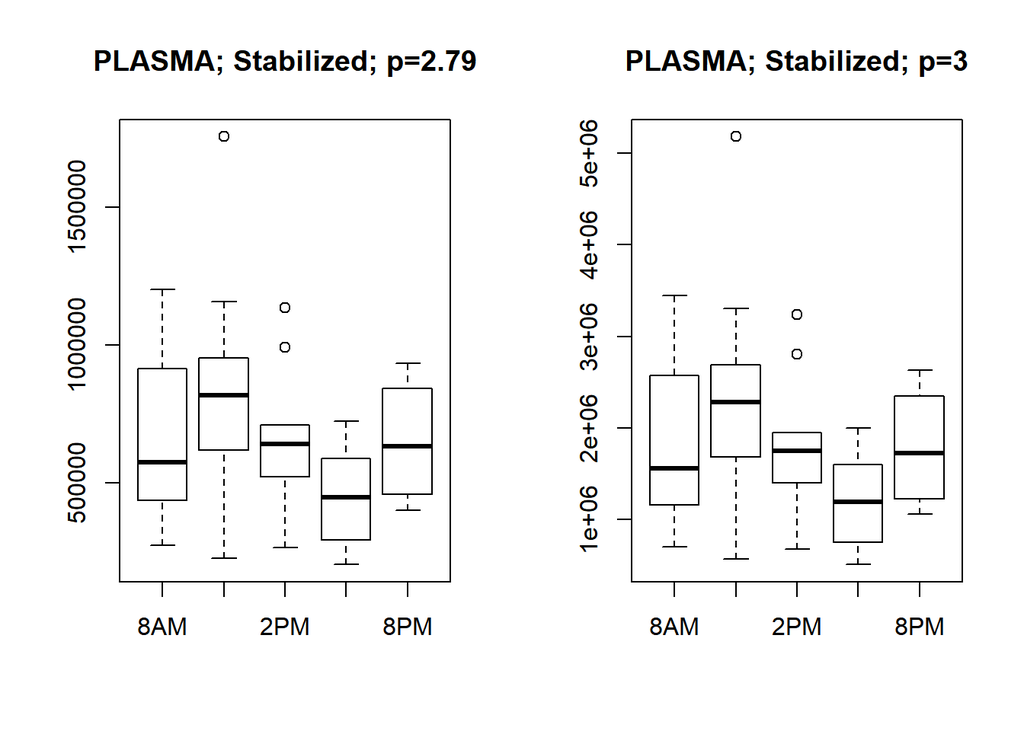

### - 다른 변환들

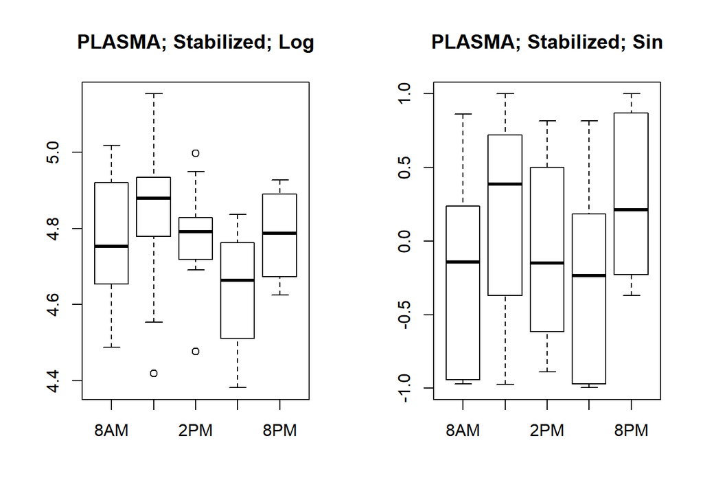

로그변환을 시도해 보았는데 이 때 분산은 세 제곱을 했을 때 보다 차이가 커 보이기 때문에 유의미한 변환으로 볼 수 없다. 그 후 원자료에 sin을 취해 변환을 해 보니 구간마다 분산이 비교적 일정해진 것을 볼 수 있다. Sin변환 한 데이터의 구간별 H-spread를 직접 구해보았다.

```r
n.Hsp1<-fivenum(sin(plasma$'8AM'))[4] - fivenum(sin(plasma$'8AM'))[2]
n.Hsp2<-fivenum(sin(plasma$'11AM'))[4] - fivenum(sin(plasma$'11AM'))[2]
n.Hsp3<-fivenum(sin(plasma$'2PM'))[4] - fivenum(sin(plasma$'2PM'))[2]
n.Hsp4<-fivenum(sin(plasma$'5PM'))[4] - fivenum(sin(plasma$'5PM'))[2]
n.Hsp5<-fivenum(sin(plasma$'8PM'))[4] - fivenum(sin(plasma$'8PM'))[2]
n.Hsp<-c(n.Hsp1,n.Hsp2,n.Hsp3,n.Hsp4,n.Hsp5)
n.Hsp
```

```
## [1] 1.179176 1.092442 1.114754 1.155317 1.097018
```

결과적으로, 구간별 H-spread의 차이가 매우 근소하게 나타나 성공적으로 분산이 안정화되었다고 볼 수 있다.

# 시간대별 평균의 차이 확인

### - Notch 활용

원 데이터와 sin변환한 데이터의 상자 그림에 notch를 추가해 구간별 median의 차이가 있는지 살펴보았다.

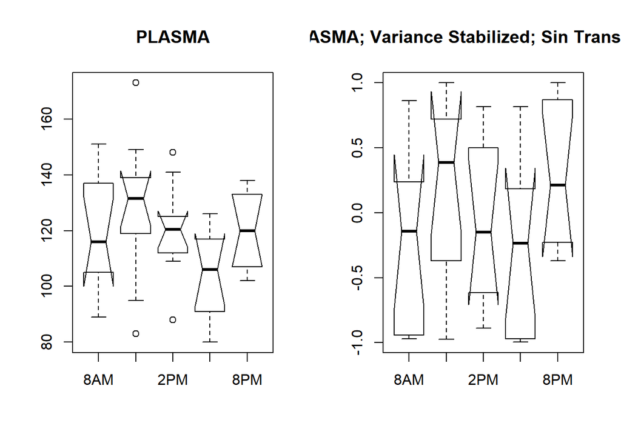

보다시피, 원자료에는 11AM과 5PM의 notch가 거의 겹치지 않아 median의 차이가 있다고 판단하지만, sin변환된 데이터에는 겹치지 않는 notch가 없기 때문에 시간대별로 혈장 농도의 median의 차이가 있다고 보지 않는다. 하지만 이 상자그림에서의 median의 비교는 각 구간별 median의 차이를 고려할 뿐 같은 사람의 변화라는 점을 고려하지 못한다는 단점이 있다.

### - Paired T-test 활용

Paired T-test를 활용하면,같은 사람의 혈당 농도 변화에 대한 시간별 차이를 알 수 있다. Paired T-test의 검정통계량은 다음과 같다.

$$\bar{D} = \frac{\sum_{i=1}^{n}(X_i-Y_i)}{n}$$
$$S_d=\sqrt{\frac{\sum{d_i^2}-\frac{(\sum{d_i})^2}{n}}{n-1}}$$

$$T=\frac{\bar{D}}{S_D/\sqrt{n}} \ \text{~} \ T_{(n-1)} \ \text{under null hypothesis}$$

```
## $p.value
## [1] 0.096292
```

```
## $p.value
## [1] 0.6135282
```

```
## $p.value
## [1] 0.02525846
```

```
## $p.value
## [1] 0.8725809
```

```
## $p.value
## [1] 0.1369929
```

```
## $p.value
## [1] 0.001084452
```

```
## $p.value
## [1] 0.3197834
```

```
## $p.value
## [1] 0.003188009
```

```
## $p.value
## [1] 0.9151492
```

```
## $p.value
## [1] 0.01863947
```

두개의 시간대를 골라 각각 t-test를 시행하면, 그 결과로 8AM과 5PM, 11AM과 5PM, 2PM과 5PM, 5PM과 8PM에서 p-valur가 0.05보다 낮아 모평균이 같다는 귀무가설이 기각됨으로써 평균에 차이가 존재한다는 결과가 나왔다.

## 결론

환자들의 혈당 농도는 시간대별로 유의미한 차이가 존재하는데, 이 차이는 8AM과 5PM, 11AM과 5PM, 2PM과 5PM, 5PM과 8PM에 나타나며, 오후 5시 가량에 혈중 농도가 유의미하게 낮아짐을 알 수 있다.

[output not shown]